# Nepal Floods Response Analysis

Author

UN Nepal & iMMAP

Modified

September 23, 2026

# Introduction

The response to the 2026 Nepal Floods is comprised of the efforts of 58 Lead Agencies and 50 Implementing Partners. According to the 5Ws dashboard, a total of 64,263 persons have been reached across 15 Municipalities. The Flash Appeal estimated 84,720 people were affected by the flooding.

## Executive summary

- The ward is a more appropriate administrative level than the municipality for planning and analysis of a response along a narrow corridor.
- Only 33.35% of all beneficiary frequencies (inclusive of double counting) in the 5Ws are reported at ward level. This percentage is likely to increase as the response goes along, though significant omissions from the first week of the response will likely never be resolved.
- Numerous wards in Bidur Municipality have been saturated with aid. Wards both further upstream and downstream have received much less assistance. Downstream areas (past Dhading) should be re-evaluated for inclusion in response plans.
- Affected wards in Nuwakot district have received much more comprehensive aid than other locations, with multiple sectors/Clusters present in most wards.
- Within the core response areas of Nuwakot, Rasuwa and Dhading, there are noticeably fewer assessments planned/conducted for Aamachhodingmo, Kalika and Kispang. Assessment coverage is highest in Bidur and Uttargaya.
- Affected wards can be broken up into 4 sub-contexts to facilitate planning and analysis:
  - **A**: Highly-impacted, entirely rural wards with lower-than-average agricultural employment.
  - **B**: Highly-impacted, entirely urban wards with lower-than-average agricultural employment.
  - **C**: Less impacted, entirely rural wards which are the poorest areas across all flood-affected wards.
  - **D**: Less impacted, entirely rural wards with high agricultural employment.

# Municipal-level summary

From the plots below, we note that:

- Bidur, Gosaikunda and Uttargaya are the municipalities to which the majority of response resources have been allocated to date. In relation to the amount of damage they suffered, Bidur and Uttargaya have received slightly more aid than Gosaikunda.
- Populations in Galchhi and Aamachhodingmo have received a high proportion of relief interventions in comparison to the scale of damage in these areas. Benighat Rorang and Siddhalek are the opposite, though being much further downstream, flood damage in these areas is likely less severe.

The municipal-level plots below allow for the comparison between the number of impacted buildings, the sum of all beneficiary frequencies in the 5Ws (which includes double counting and is indicative of how humanitarian partners have allocated their resources to date) and the total population of the affected wards.

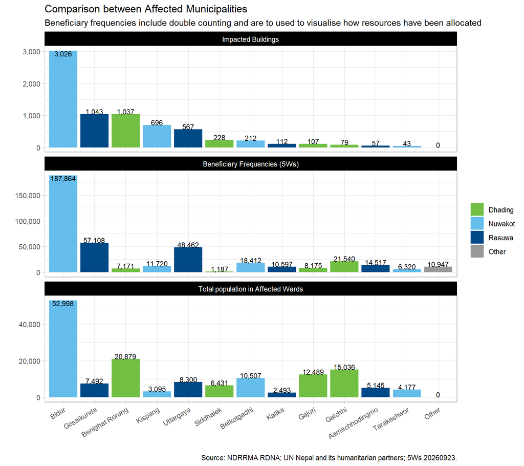

The map below shows individuals reached in the 5Ws with OCHA’s formula for avoiding double counting applied. Though the scale of the response in Bidur is very large, and District authorities have indicated that the municipality is saturated, the total number of individuals reached is only about double what it is in Gosaikunda.

As a final note, the 5Ws only captures the response achievements of UN Nepal and its humanitarian partners. For a more comprehensive understanding of gaps, data on the government’s response is being sought.

[figure not shown]

Click map for full-size version

# Ward-level analysis

The ward is a more appropriate administrative level for analysis than the municipality. The municipalities of Bidur, Galchhi, Gosaikunda and Uttargaya are bisected by the Trishuli river and without ward-level data, it is not possible to tell which side of the river activities are occurring on.

Only 33.35% of all beneficiary frequencies in the 5Ws are reported at ward level. Whilst most partners are able to report current activities at the ward level, backfilling the achievements from the first week of the response with ward-level data has proved to be challenging: many relief commodities were provided to municipal authorities or “distributed” to warehouses in district or municipal seats and obtaining last-mile data for these will be challenging.

Bearing these limitations mind, the plots below shows ward-level 5W achievements. We have used the sum of all beneficiary frequencies reached, without regard for double counting, as it provides an idea how agencies have allocated their resources to date.

On the x-axis of the plots below is the number of beneficiary frequencies reached per ward. On the y-axis is the number of beneficiary frequencies, as a % of the ward’s population. The size of each point indicates each ward’s share of damaged buildings: as with the municipal-level comparisons, the scale of response interventions does not always align with the scale of damage in each area.

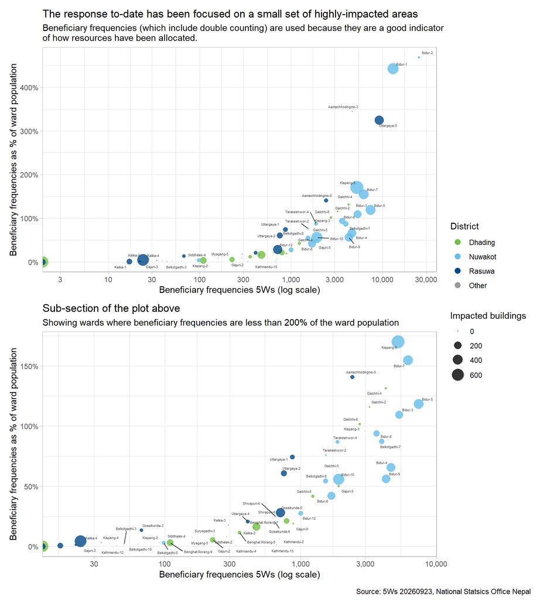

This is also evident in the map of beneficiary frequencies in the map below.

[figure not shown]

Click map for full-size version

Also from the map, we note a non-insignificant amount of humanitarian assistance that are outside of the affected areas. These are summarised in the table below. Some of these interventions were in more distant holding centres, like those in Kathmandu, but this will need to be investigated in more detail.

Beneficiary frequencies by type of ward, 5Ws 20260923

| Ward category | Beneficiary frequencies (5Ws) | % of total |
| --- | --- | --- |
| Affected area | 119,527 | 88.71 |
| Outside affected area | 15,213 | 11.29 |

## Multi-sector programming

The effects of the floods were severe and multidimensional, with numerous cascading effects. The loss of life, housing and key infrastructure have given rise to Protection, WASH, Health and Nutrition and Livelihoods needs.

Area-based programming is key when each ward is subject to multiple, varying contextual specificities such as the severity of access constraints, rate of urbanisation, severity of flood damage and pre-existing vulnerability and poverty.

[figure not shown]

Click map for full-size version

Sector presence is densest in Nuwakot. Though even within municipalities as well covered as Bidur, there is a marked difference when it comes to sector/Cluster presence on the western bank of the river.

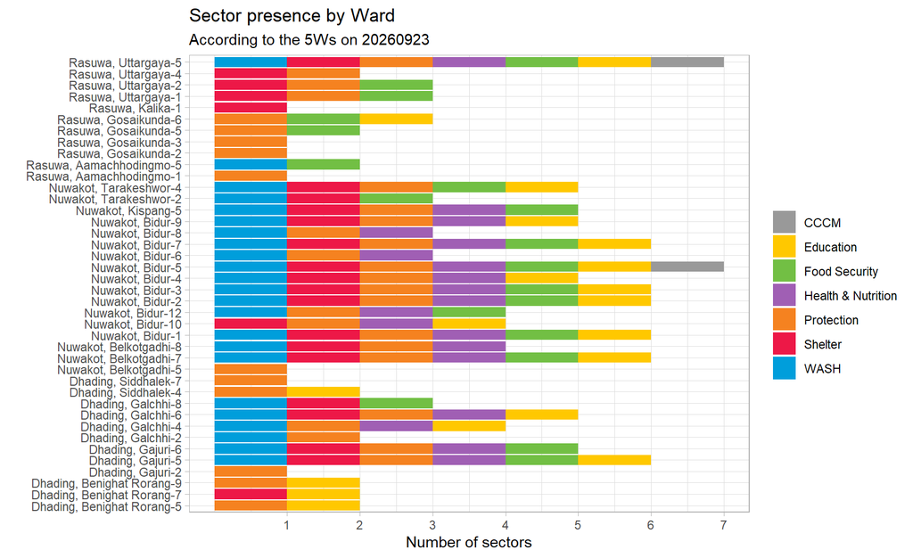

# Assessment coverage

[figure not shown]

Click map for full-size version

Bidur in Nuwakot and Uttargaya in Rasuwa are the most assessed locations across the flood-affected areas. Within the core response areas of Nuwakot, Rasuwa and Dhading, there are noticeably fewer assessments planned/conducted for Aamachhodingmo, Kalika and Kispang. And, as had been noted in previous IM meetings, there is much lower coverage in the downstream parts of the affected areas, especially in the areas past Dhading.

In terms of assessed sectors, Shelter and NFIs and CCCM were the subject of the highest number of assessments, followed by Food Security and Health. Of the 12 assessments currently recorded in the [Assessment Registry](https://docs.google.com/spreadsheets/d/1UwPxOlgHHFpaKJd3NZUIjgBrSr7dVdTzN7GXaM6sMQk/edit?usp=drive_link), only 2 were specific to affected facilities (pertaining to Health); the other 10 were more wide-ranging and will be expected to provide details about the living conditions, coping mechanisms and future plans of affected communities.

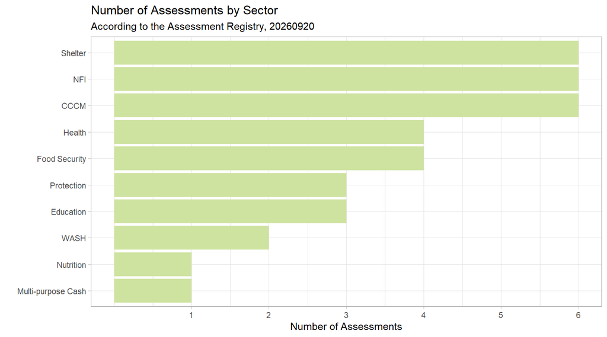

Given the various methodologies being employed and differing sampling frames employed, there is no mathematical way to reconcile the results of these various assessments. However, more in-depth secondary data reviews should be possible for Bidur and Belkotgadhi in Nuwakot, Gosaikunda and Uttargaya in Rasuwa, and Galchhi and Gajuri in Dhading. However, reconciling planned and conducted assessments into the 4 sub-contexts mentioned in the next section will be much easier.

For more details, please refer to the Assessment Registry [here](https://docs.google.com/spreadsheets/d/1UwPxOlgHHFpaKJd3NZUIjgBrSr7dVdTzN7GXaM6sMQk/edit?usp=drive_link).

# Prioritisation and sub-contexts

To aid sampling for assessments as well as operational planning and analysis, we have performed K-means clustering on the affected wards. K-means clustering is a machine learning method that groups data points based on their similarities.

The table below provides an overview of the means of a few of the selected variables which we used to perform the clustering:

K-means Clusters, Means of Selected Indicators and Total Ward Population

| Group | Population Density | Total Dependency Ratio | Agricultural Employement % | Poorest Quintile % | Impacted Buildings | Population |
| --- | --- | --- | --- | --- | --- | --- |
| A | 234.89 | 45.41 | 44.88 | 8.12 | 247.27 | 34,854 |
| B | 720.21 | 49.84 | 51.89 | 4.57 | 205.00 | 69,079 |
| C | 82.14 | 60.33 | 76.31 | 47.96 | 49.17 | 24,340 |
| D | 181.79 | 51.70 | 72.61 | 14.20 | 32.67 | 78,799 |

The affected wards have been been clustered into 4 groups:

**A**: Highly-impacted, entirely rural wards with lower-than-average agricultural employment.

**B**: Highly-impacted, entirely urban wards with lower-than-average agricultural employment.

**C**: Less impacted, entirely rural wards which are the poorest areas across all flood-affected wards.

**D**: Less impacted, entirely rural wards with high agricultural employment.

**A** and **B** should be prioritised, with different programme sets, given their greatly different population densities and rates of urbanisation. The types of reconstruction and infrastructure needs in both areas will also vary greatly.

Activities in **C** should be seek seek to bridge recovery with longer-term development and poverty alleviation interventions given high percentage of poor persons in these areas.

These groups are plotted in the map below:

[figure not shown]

Click map for full-size version

The specific indicators used in the clustering were:

- Total population
- Population density
- Sex ratio
- Average household size
- Total dependency ratio
- % Rural
- Disability prevalence rate
- Agricultural employment %
- % Poorest quintile
- % Inadequate house quality
- % Unimproved drinking water
- % Unimproved sanitation
- Impacted buildings

The dataset containing these groups may be downloaded [here](https://drive.google.com/drive/folders/1dHDzi-gLe0ldOduwGwVUUcas7Qar2CEK?usp=drive_link).

# Reference table

[output not shown]

[output cut: 59 more lines]

## Useful links and datasets

### [Digitised NDRRMA Municipal Damage Tables](https://drive.google.com/drive/folders/1GehdusDNji6HGQGQ6R7cEHNJC3BwwNau?usp=drive_link)

### [Ward groups, including Impacted Buildings by Ward](https://drive.google.com/drive/folders/1dHDzi-gLe0ldOduwGwVUUcas7Qar2CEK?usp=drive_link)

### [5W Dashboard](https://app.powerbi.com/view?r=eyJrIjoiZTQ0MGE1NWEtOWJlMi00YmU4LWFhYjMtMTg0OTRmNTRmMGQ1IiwidCI6IjBmOWUzNWRiLTU0NGYtNGY2MC1iZGNjLTVlYTQxNmU2ZGM3MCIsImMiOjh9)

### [Consolidated Census Ward-level Household and Population](https://drive.google.com/drive/folders/1gNkJJR6Q4psoCrWyBcUyzqL9wcKVVRbb?usp=drive_link)

Variables include a breakdown of housing materials, wealth quintile, school attendance and household WASH.

### [Logistics Cluster Access Map](https://logie.logcluster.org/?op=npl)

Updated regularly.